# 40 years Video Game Sales Analysis and predicting sales for different countries

##### **Group Member - Vaishnavi Dubal, Jason Trotman, Maheswara Reddy, Prachi Rathod**

## **Introduction**

### **Overview**

Video games have had a great impact on our childhood since we grew up playing video gmaes and all are still very much attached to our childhood memories and try to relive it by playing the newer version of the older games. We have see that the video game industry has changed a lot during the last forty years and we will be analyzing the Video Game sales and critic/users overview of these games based on their genre, PLatforms, publisher, developers. The data that we are using for this project contains data from year 1980 - 2020. We will be exploring the dataset to see any trends in the data and do exploratory data analysis to gain insights from the data.

### **Business Problem**

We will predict the Video game sales of a for sales in Japan, Europe, North America, Global and other basesd on the Year of Release features.

### **Dataset Overview**

The data is from public data recourse: [Kaggle](https://www.kaggle.com/gregorut/videogamesales/code?datasetId=284&sortBy=voteCount)

The data set structure demonstrates that it has 16 features and around 16719 records of Video Games across Japan, Europe, North America, Global and other from the year 1980 - 2020.

### **Approach**

- We will be using the training dataset to train our model and test dataset to predict the sales of the video
- We will conduct data cleaning and perform an exploratory data analysis to generate some insights influence of the following ratings, year of release, frequency of games in the specific years on the sales of the video game:
- We plan to develop a Linear Regression model and make use of the arima forecast model to predict the behavior of video game sales in the coming years
- We will be using the RMSE and variance score as a metric to determine the performance of model in terms of prediction

## **Exploratory Data Analysis**

### **Import Dataset and Library**

##Loading libraries

```r
library(dplyr)
```

```r
library(ggplot2)
library(sqldf)
```

##Loading the data set

```r
data <- read.csv("C:/Users/prach/OneDrive - University of Cincinnati/Desktop/Fall 2021 courses/Data Analysis methods/final_porject_dam/Video_Games_Sales_as_at_22_Dec_2016.csv")
```

##Looking at the structure of the dataset

```r
str(data)
```

```
## 'data.frame':    16719 obs. of  16 variables:
##  $ Name           : chr  "Wii Sports" "Super Mario Bros." "Mario Kart Wii" "Wii Sports Resort" ...
##  $ Platform       : chr  "Wii" "NES" "Wii" "Wii" ...
##  $ Year_of_Release: int  2006 1985 2008 2009 1996 1989 2006 2006 2009 1984 ...
##  $ Genre          : chr  "Sports" "Platform" "Racing" "Sports" ...
##  $ Publisher      : chr  "Nintendo" "Nintendo" "Nintendo" "Nintendo" ...
##  $ NA_Sales       : num  41.4 29.1 15.7 15.6 11.3 ...
##  $ EU_Sales       : num  28.96 3.58 12.76 10.93 8.89 ...
##  $ JP_Sales       : num  3.77 6.81 3.79 3.28 10.22 ...
##  $ Other_Sales    : num  8.45 0.77 3.29 2.95 1 0.58 2.88 2.84 2.24 0.47 ...
##  $ Global_Sales   : num  82.5 40.2 35.5 32.8 31.4 ...
##  $ Critic_Score   : int  76 NA 82 80 NA NA 89 58 87 NA ...
##  $ Critic_Count   : int  51 NA 73 73 NA NA 65 41 80 NA ...
##  $ User_Score     : chr  "8" "" "8.3" "8" ...
##  $ User_Count     : int  322 NA 709 192 NA NA 431 129 594 NA ...
##  $ Developer      : chr  "Nintendo" "" "Nintendo" "Nintendo" ...
##  $ Rating         : chr  "E" "" "E" "E" ...
```

##Handling the null values and blankspaces in the data

```r
#checking for null values in the data
colSums(is.na(data))
```

```
##            Name        Platform Year_of_Release           Genre       Publisher
##               0               0             269               0               0
##        NA_Sales        EU_Sales        JP_Sales     Other_Sales    Global_Sales
##               0               0               0               0               0
##    Critic_Score    Critic_Count      User_Score      User_Count       Developer
##            8581            8582               0            9129               0
##          Rating
##               0
```

We can see that there are 269 null values in the Year_of_release and if we have look at the data we can see that there are blank spaces in the data as well. We can take care of the blank space by replacing them with NA in the data. For null values in the data we will be dropping the null values during our analysis process

```r
data$Publisher[data$Publisher == ""] <- NA
data$Platform[data$Platform == ""] <- NA
data$User_Score[data$User_Score == ""] <- NA
data$Developer[data$Developer == ""] <- NA
data$Rating[data$Rating == ""] <- NA
data$Genre[data$Genre == ""] <- NA
```

## Average sales from 1980 - 2020

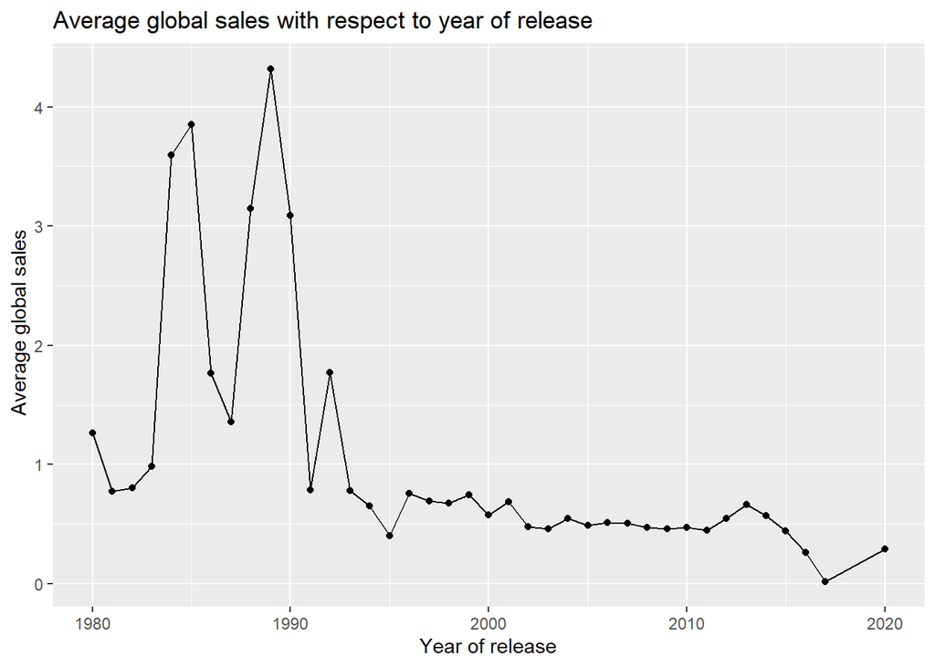

```r
global_Sales_over_the_year <- aggregate(data$Global_Sales, list(data$Year_of_Release), FUN=mean)
year_release <- global_Sales_over_the_year[,c('Group.1')]
average_global_sales <- global_Sales_over_the_year[,c('x')]
ggplot(data=global_Sales_over_the_year, aes(x=year_release, y=average_global_sales, group=1)) +
  geom_line()+
  geom_point()+
  labs(x = "Year of release", y = " Average global sales", title = "Average global sales with respect to year of release")
```

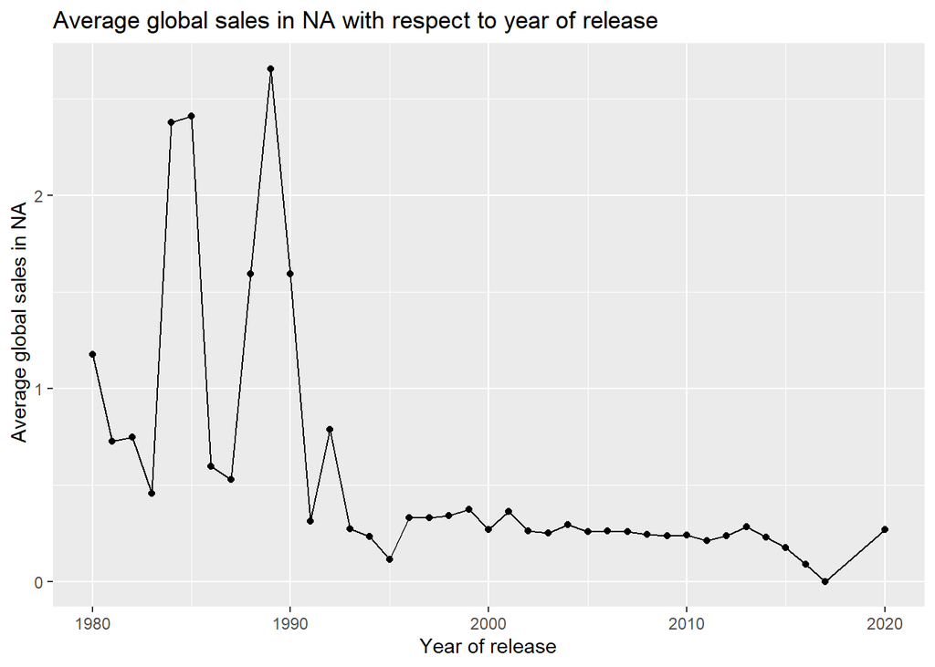

```r
#NA Sales
global_Sales_over_the_year_na <- aggregate(data$NA_Sales, list(data$Year_of_Release), FUN=mean)
year_release <- global_Sales_over_the_year[,c('Group.1')]
average_global_sales_na <- global_Sales_over_the_year_na[,c('x')]
ggplot(data=global_Sales_over_the_year_na, aes(x=year_release, y=average_global_sales_na, group=1)) +
  geom_line()+
  geom_point()+
  labs(x = "Year of release", y = " Average global sales in NA", title = "Average global sales in NA with respect to year of release")
```

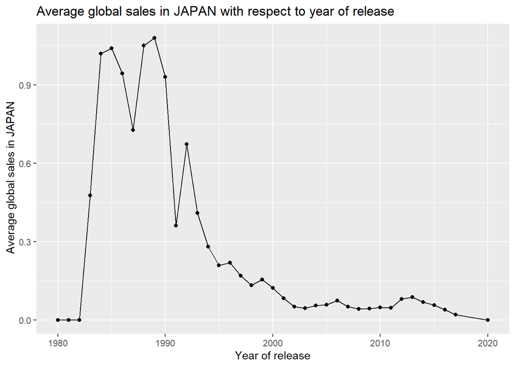

```r
#japan sales

global_Sales_over_the_year_japan <- aggregate(data$JP_Sales, list(data$Year_of_Release), FUN=mean)
year_release <- global_Sales_over_the_year_japan[,c('Group.1')]
average_global_sales_japan <- global_Sales_over_the_year_japan[,c('x')]
ggplot(data=global_Sales_over_the_year_japan, aes(x=year_release, y=average_global_sales_japan, group=1)) +
  geom_line()+
  geom_point()+
  labs(x = "Year of release", y = " Average global sales in JAPAN", title = "Average global sales in JAPAN with respect to year of release")
```

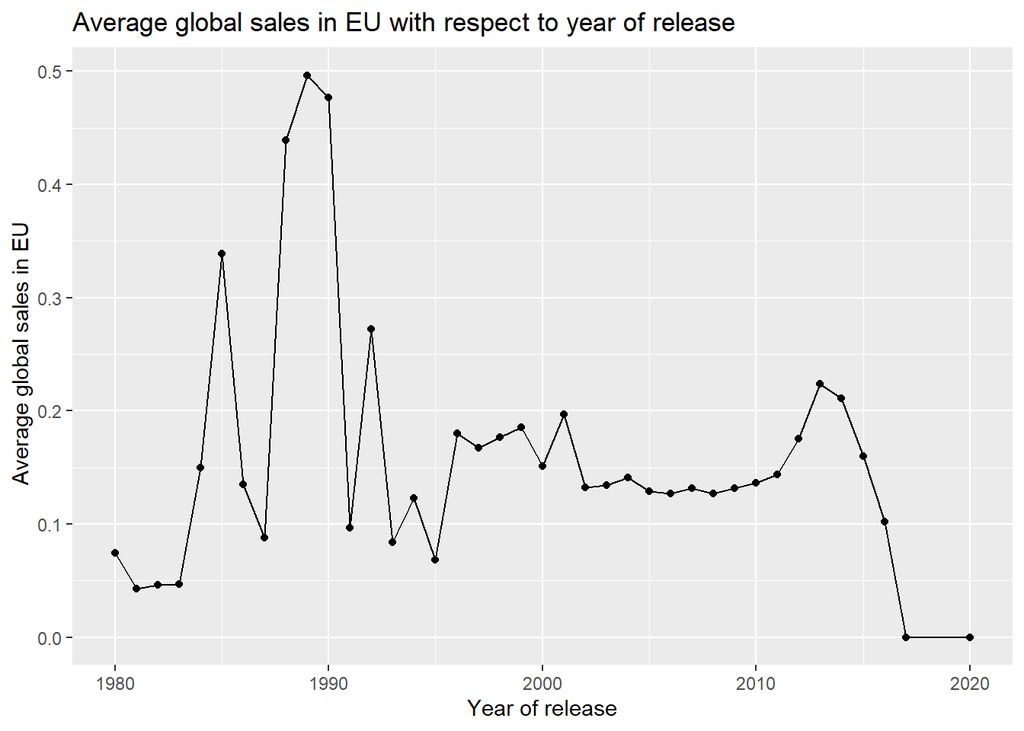

```r
#EU sales
global_Sales_over_the_year_eu <- aggregate(data$EU_Sales, list(data$Year_of_Release), FUN=mean)
year_release <- global_Sales_over_the_year_eu[,c('Group.1')]
average_global_sales_eu <- global_Sales_over_the_year_eu[,c('x')]
ggplot(data=global_Sales_over_the_year_eu, aes(x=year_release, y=average_global_sales_eu, group=1)) +
  geom_line()+
  geom_point()+
  labs(x = "Year of release", y = " Average global sales in EU", title = "Average global sales in EU with respect to year of release")
```

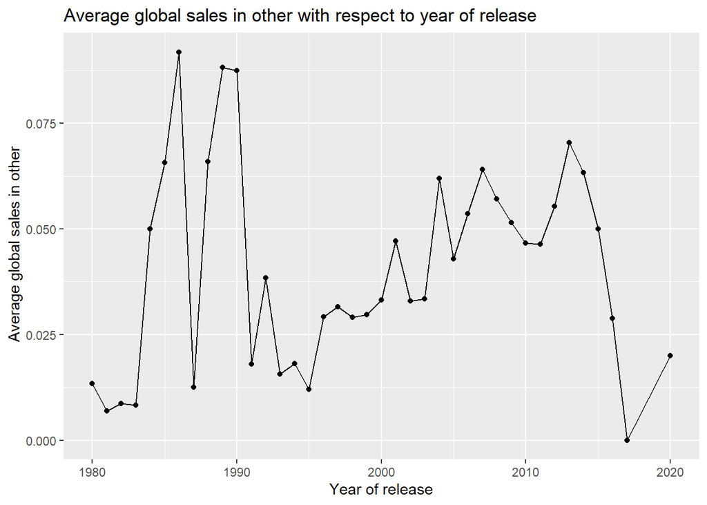

```r
#other sales
global_Sales_over_the_year_other <- aggregate(data$Other_Sales, list(data$Year_of_Release), FUN=mean)
year_release <- global_Sales_over_the_year_other[,c('Group.1')]
average_global_sales_other <- global_Sales_over_the_year_other[,c('x')]
ggplot(data=global_Sales_over_the_year_other, aes(x=year_release, y=average_global_sales_other, group=1)) +
  geom_line()+
  geom_point()+
  labs(x = "Year of release", y = " Average global sales in other", title = "Average global sales in other with respect to year of release")
```

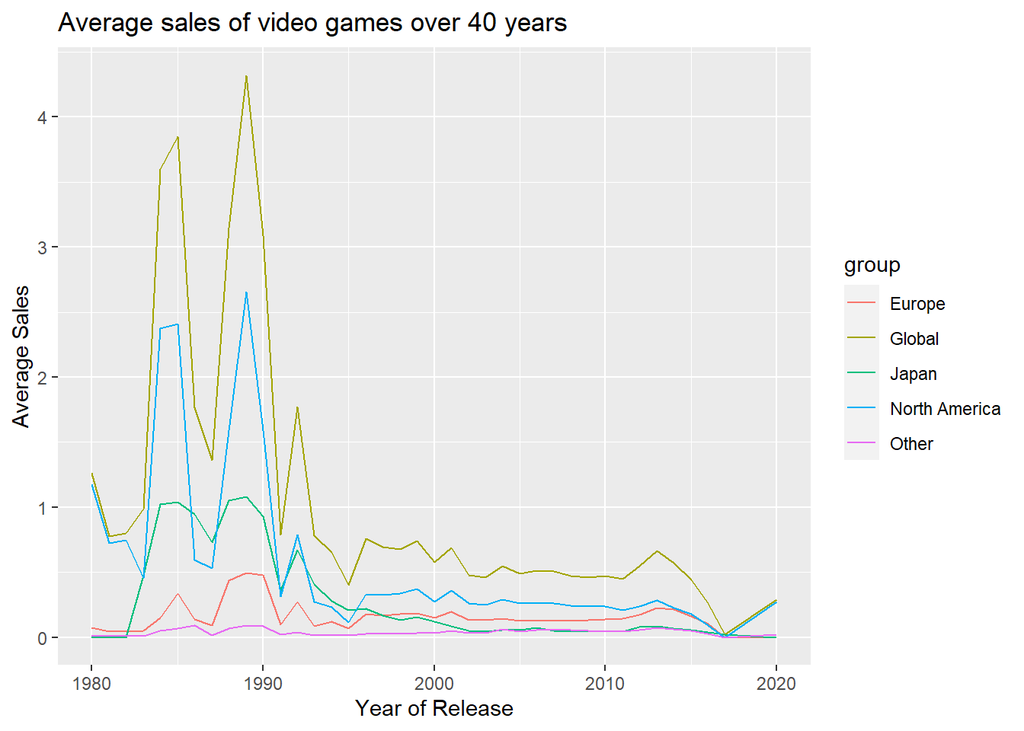

```r
global_Sales_over_the_year <- mutate(global_Sales_over_the_year, EU = global_Sales_over_the_year_eu$x)
global_Sales_over_the_year <- mutate(global_Sales_over_the_year, NorthAmerica = global_Sales_over_the_year_na$x)
global_Sales_over_the_year <- mutate(global_Sales_over_the_year, Japan = global_Sales_over_the_year_japan$x)
global_Sales_over_the_year <- mutate(global_Sales_over_the_year, Other = global_Sales_over_the_year_other$x)

sales_overall <- data.frame(x = global_Sales_over_the_year$Group.1,                            # Reshape data frame
                       y = c(global_Sales_over_the_year$x, global_Sales_over_the_year$EU, global_Sales_over_the_year$NorthAmerica, global_Sales_over_the_year$Japan, global_Sales_over_the_year$Other),
                       group = c(rep("Global", nrow(global_Sales_over_the_year)),
                                 rep("Europe", nrow(global_Sales_over_the_year)),
                                 rep("North America", nrow(global_Sales_over_the_year)),
                                 rep("Japan", nrow(global_Sales_over_the_year)),
                                 rep("Other", nrow(global_Sales_over_the_year))))
ggplot(sales_overall, aes(x, y, col = group)) +
  geom_line()+
  labs(x = "Year of Release" , y = "Average Sales" , title = "Average sales of video games over 40 years")
```

## Analyzing how average sales varied across all the years

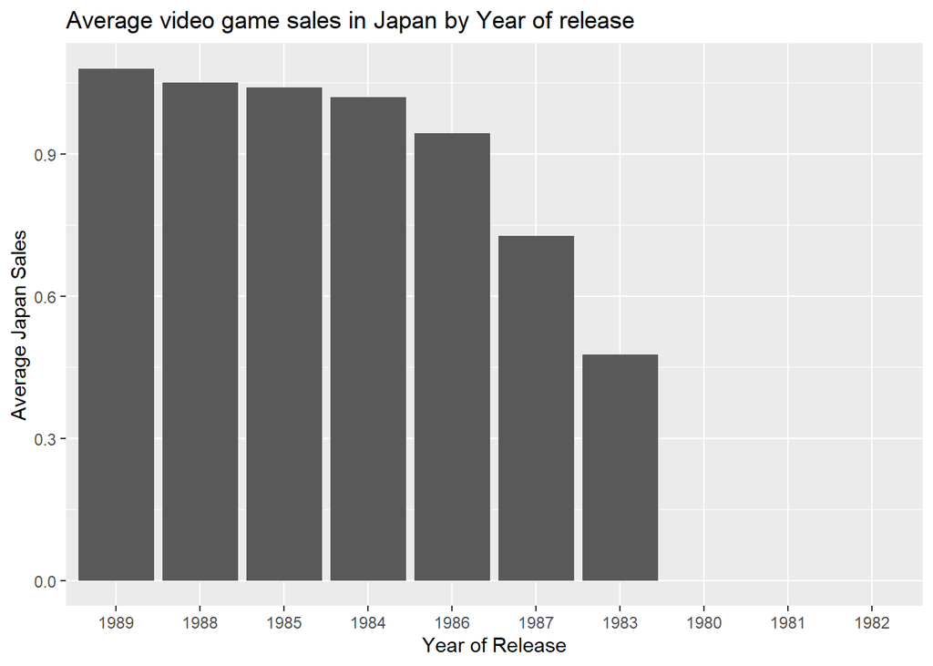

```r
JP_sales <- sqldf('select avg(JP_Sales) as average_JP_sales, Year_of_Release from data where Year_of_Release is not null group by Year_of_Release limit(10)')
ggplot(data = JP_sales, aes(x = reorder(Year_of_Release, -average_JP_sales), y = average_JP_sales)) +
  geom_bar(stat = "identity") +
  labs(x = "Year of Release" , y = "Average Japan Sales" , title = "Average video game sales in Japan by Year of release ")
```

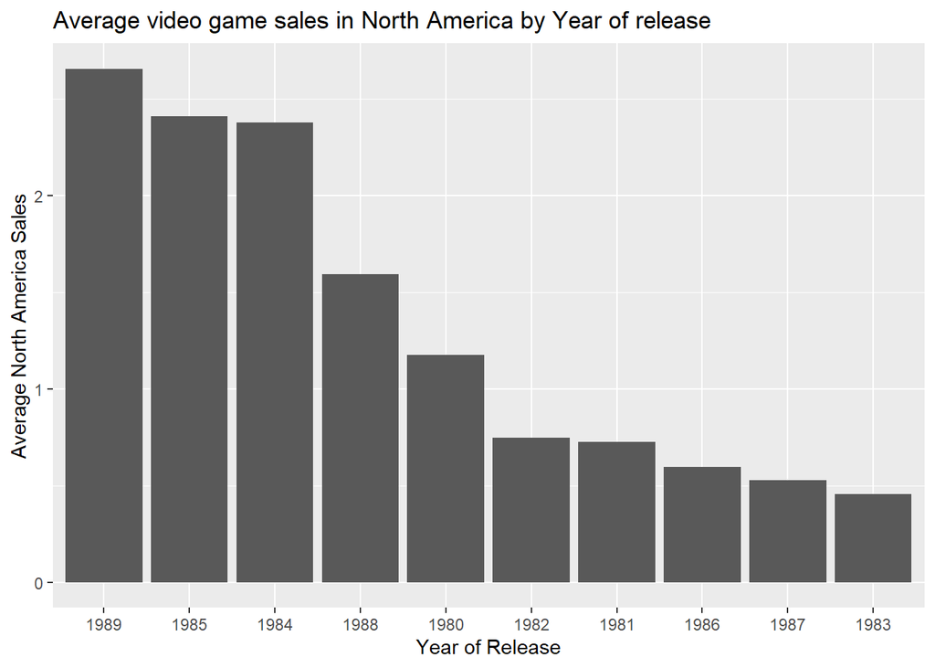

```r
NA_sales <- sqldf('select avg(NA_Sales) as average_NA_sales, Year_of_Release from data where Year_of_Release is not null group by Year_of_Release limit(10)')
ggplot(data = NA_sales, aes(x = reorder(Year_of_Release, -average_NA_sales), y = average_NA_sales)) +
  geom_bar(stat = "identity") +
  labs(x = "Year of Release" , y = "Average North America Sales" , title = "Average video game sales in North America by Year of release ")
```

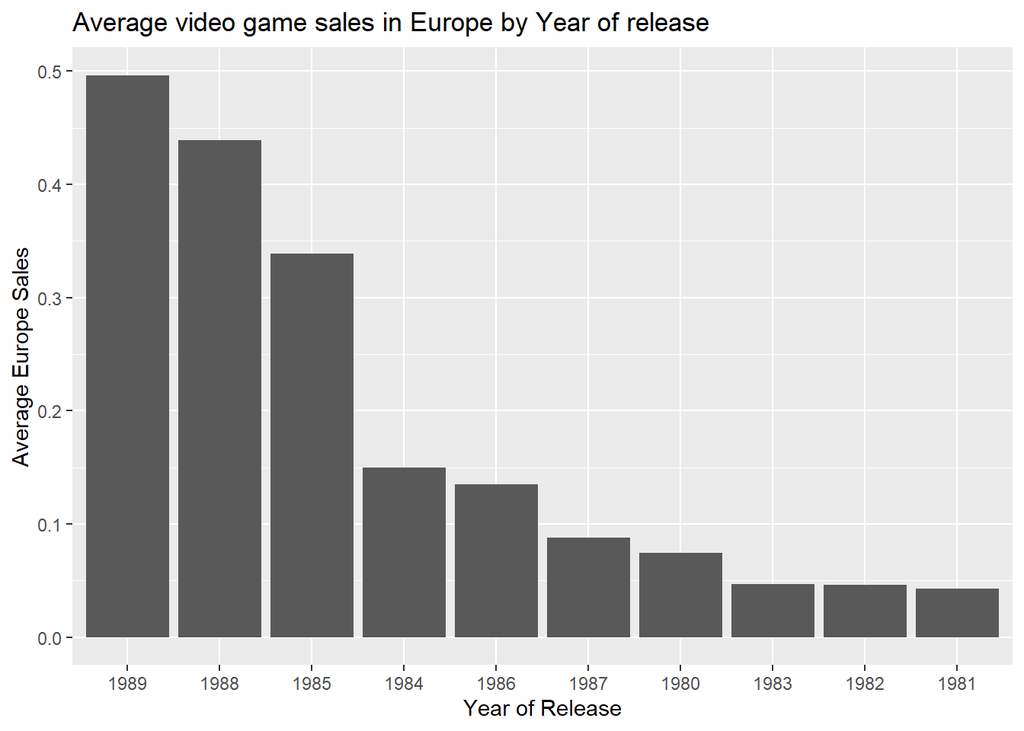

```r
EU_sales <- sqldf('select avg(EU_Sales) as average_EU_sales, Year_of_Release from data where Year_of_Release is not null group by Year_of_Release limit(10)')
ggplot(data = EU_sales, aes(x = reorder(Year_of_Release, -average_EU_sales), y = average_EU_sales)) +
  geom_bar(stat = "identity") +
  labs(x = "Year of Release" , y = "Average Europe Sales" , title = "Average video game sales in Europe by Year of release ")
```

[figure not shown]

```r
Global_sales <- sqldf('select avg(EU_Sales) as average_Global_sales, Year_of_Release from data where Year_of_Release is not null group by Year_of_Release limit(10)')
ggplot(data = Global_sales, aes(x = reorder(Year_of_Release, -average_Global_sales), y = average_Global_sales)) +
  geom_bar(stat = "identity") +
  labs(x = "Year of Release" , y = "Average Global Sales" , title = "Average video game sales Globally  by Year of release ")
```

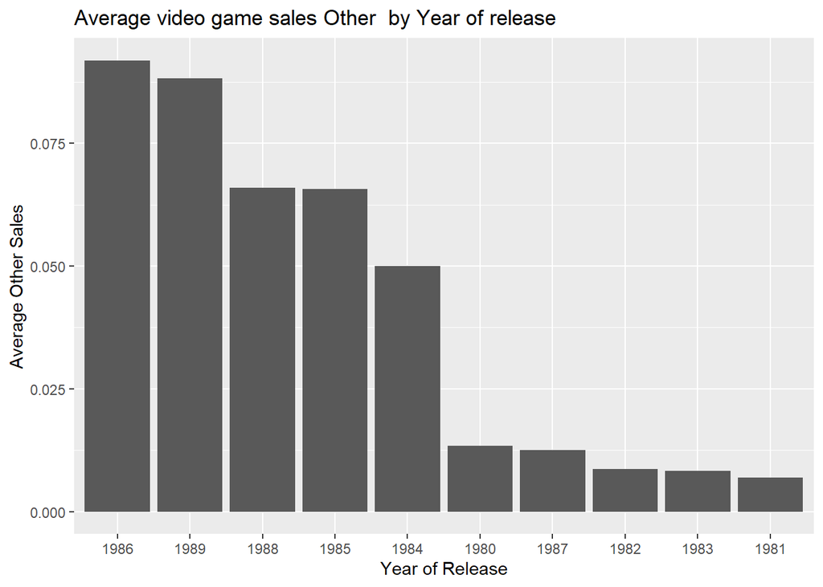

```r
Other_sales <- sqldf('select avg(Other_Sales) as average_Other_sales, Year_of_Release from data where Year_of_Release is not null group by Year_of_Release limit(10)')
ggplot(data = Other_sales, aes(x = reorder(Year_of_Release, -average_Other_sales), y = average_Other_sales)) +
  geom_bar(stat = "identity") +
  labs(x = "Year of Release" , y = "Average Other Sales" , title = "Average video game sales Other  by Year of release ")
```

## How ratings have affected the Global sales of the data

[figure not shown]

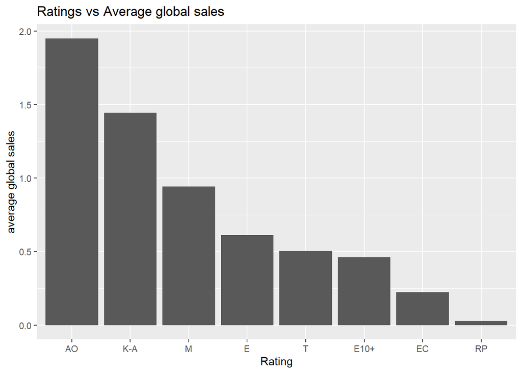

```r
#Ratings vs sales
ratings_vs_sales <- sqldf('select Rating, avg(global_sales) as average_global_Sales from data where Rating is not null group by Rating order by average_global_sales desc')
ggplot(data = ratings_vs_sales , aes(x = reorder(Rating, -average_global_Sales), y = average_global_Sales)) +
  geom_bar(stat = "identity") +
  labs(x = "Rating" , y = "average global sales" , title = "Ratings vs Average global sales")
```

From the above analysis we can that the games with rating AO i.e Adults only have the highest video game sales along with K-A Kids to Adult followed by Mature, Everyone and Teen.

The Games which have RP i.e Rating Pending have the lowest sales globally

## Evolution of the Video Game Industry

Since we have data from the Years 1980 - 2020 i.e 40 years of data, we wanted to explore how the video game industry has changed over the years. Hence we divided the data into four buckets i.e from of 10 years and we will be exploring the trends in the data based on Games, Genre, Publisher, Platforms

```r
#Bucket 1 from Year 1980 - 1990

bucket_1 <- sqldf('select Name, count(Name) as Games from data where Year_of_Release BETWEEN "1980" AND "1990" and Name is not null group by Name order by Games desc limit (10)')
bucket_1
```

```
##                  Name Games
## 1              Tetris     2
## 2              Tennis     2
## 3              Popeye     2
## 4             Pac-Man     2
## 5         Mario Bros.     2
## 6          Ice Hockey     2
## 7                Golf     2
## 8           Dr. Mario     2
## 9         Donkey Kong     2
## 10 Disney's DuckTales     2
```

```r
genre_1 <- sqldf('select Genre, count(Genre) as Games from data where Year_of_Release BETWEEN "1980" AND "1990" and Name is not null group by Name order by Games desc limit (10)')
genre_1
```

```
##       Genre Games
## 1    Puzzle     2
## 2    Sports     2
## 3  Platform     2
## 4    Puzzle     2
## 5  Platform     2
## 6    Sports     2
## 7    Sports     2
## 8    Puzzle     2
## 9  Platform     2
## 10 Platform     2
```

```r
Platform_1 <- sqldf('select Platform, count(Platform) as Games from data where Year_of_Release BETWEEN "1980" AND "1990" and Name is not null group by Name order by Games desc limit (10)')
Platform_1
```

```
##    Platform Games
## 1        GB     2
## 2       NES     2
## 3       NES     2
## 4        GB     2
## 5       NES     2
## 6       NES     2
## 7       NES     1
## 8        GB     1
## 9       NES     1
## 10      NES     1
```

```r
Publisher_1 <- sqldf('select Publisher, count(Publisher) as Games from data where Year_of_Release BETWEEN "1980" AND "1990" and Name is not null group by Name order by Games desc limit (10)')
Publisher_1
```

```
##    Publisher Games
## 1   Nintendo     2
## 2   Nintendo     2
## 3   Nintendo     2
## 4      Atari     2
## 5   Nintendo     2
## 6   Nintendo     2
## 7   Nintendo     2
## 8   Nintendo     2
## 9     Coleco     2
## 10    Capcom     2
```

```r
bucket_2 <- sqldf('select Name, count(Name) as Games from data where Year_of_Release BETWEEN "1991" AND "2001" and Name is not null group by Name order by Games desc limit (10)')
bucket_2
```

```
##                                     Name Games
## 1                        Madden NFL 2002     5
## 2                           SimCity 2000     4
## 3  Harry Potter and the Sorcerer's Stone     4
## 4             Dave Mirra Freestyle BMX 2     4
## 5               Tony Hawk's Pro Skater 3     3
## 6               Tony Hawk's Pro Skater 2     3
## 7                 Tony Hawk's Pro Skater     3
## 8                The Simpsons: Road Rage     3
## 9               The King of Fighters '96     3
## 10              The King of Fighters '95     3
```

```r
genre_2 <- sqldf('select Genre, count(Genre) as Games from data where Year_of_Release BETWEEN "1991" AND "2001" and Name is not null group by Name order by Games desc limit (10)')
genre_2
```

```
##         Genre Games
## 1      Sports     5
## 2  Simulation     4
## 3      Action     4
## 4      Sports     4
## 5      Sports     3
## 6      Sports     3
## 7      Sports     3
## 8      Racing     3
## 9    Fighting     3
## 10   Fighting     3
```

```r
library(sqldf)
Platform_2 <- sqldf('select Platform, count(Platform) as Games from data where Year_of_Release BETWEEN "1991" AND "2001" and Name is not null group by Name order by Games desc limit (10)')
Platform_2
```

```
##    Platform Games
## 1       PS2     5
## 2        PC     4
## 3        PS     4
## 4       PS2     4
## 5       PS2     3
## 6        PS     3
## 7        PS     3
## 8       PS2     3
## 9       SAT     3
## 10      SAT     3
```

```r
Publisher_2 <- sqldf('select Publisher, count(Publisher) as Games from data where Year_of_Release BETWEEN "1991" AND "2001" and Name is not null group by Name order by Games desc limit (10)')
Publisher_2
```

```
##                Publisher Games
## 1        Electronic Arts     5
## 2                  Maxis     4
## 3        Electronic Arts     4
## 4  Acclaim Entertainment     4
## 5             Activision     3
## 6             Activision     3
## 7             Activision     3
## 8        Electronic Arts     3
## 9                    SNK     3
## 10          SNK Playmore     3
```

```r
bucket_3 <- sqldf('select Name, count(Name) as Games from data where Year_of_Release BETWEEN "2001" AND "2011" and Name is not null group by Name order by Games desc limit (10)')
bucket_3
```

```
##                                         Name Games
## 1                                Ratatouille     9
## 2                              Madden NFL 08     8
## 3                              Madden NFL 07     8
## 4    LEGO Star Wars II: The Original Trilogy     8
## 5                                       Cars     8
## 6                                     Wall-E     7
## 7                        Tomb Raider: Legend     7
## 8                                 The Sims 2     7
## 9                                  Surf's Up     7
## 10 Star Wars The Clone Wars: Republic Heroes     7
```

```r
genre_3 <- sqldf('select Genre, count(Genre) as Games from data where Year_of_Release BETWEEN "2001" AND "2011" and Name is not null group by Name order by Games desc limit (10)')
genre_3
```

```
##         Genre Games
## 1      Action     9
## 2      Sports     8
## 3      Sports     8
## 4      Action     8
## 5      Racing     8
## 6    Platform     7
## 7      Action     7
## 8  Simulation     7
## 9      Sports     7
## 10     Action     7
```

```r
Platform_3 <- sqldf('select Platform, count(Platform) as Games from data where Year_of_Release BETWEEN "2001" AND "2011" and Name is not null group by Name order by Games desc limit (10)')
Platform_3
```

```
##    Platform Games
## 1        DS     9
## 2       PS2     8
## 3       PS2     8
## 4       PS2     8
## 5       PS2     8
## 6        DS     7
## 7       PS2     7
## 8       PSP     7
## 9       PS2     7
## 10      Wii     7
```

```r
Publisher_3 <- sqldf('select Publisher, count(Publisher) as Games from data where Year_of_Release BETWEEN "2001" AND "2011" and Name is not null group by Name order by Games desc limit (10)')
Publisher_3
```

```
##            Publisher Games
## 1                THQ     9
## 2    Electronic Arts     8
## 3    Electronic Arts     8
## 4          LucasArts     8
## 5                THQ     8
## 6                THQ     7
## 7  Eidos Interactive     7
## 8    Electronic Arts     7
## 9            Ubisoft     7
## 10         LucasArts     7
```

```r
bucket_4 <- sqldf('select Name, count(Name) as Games from data where Year_of_Release BETWEEN "2011" AND "2020" and Name is not null group by Name order by Games desc limit (10)')
bucket_4
```

```
##                            Name Games
## 1      LEGO Marvel Super Heroes     9
## 2                       FIFA 14     9
## 3      The LEGO Movie Videogame     8
## 4                      Terraria     8
## 5  Lego Batman 3: Beyond Gotham     8
## 6               LEGO The Hobbit     8
## 7           LEGO Jurassic World     8
## 8                FIFA Soccer 13     8
## 9                       FIFA 15     8
## 10        Angry Birds Star Wars     8
```

```r
genre_4 <- sqldf('select Genre, count(Genre) as Games from data where Year_of_Release BETWEEN "2011" AND "2020" and Name is not null group by Name order by Games desc limit (10)')
genre_4
```

```
##       Genre Games
## 1    Action     9
## 2    Sports     9
## 3    Action     8
## 4    Action     8
## 5    Action     8
## 6    Action     8
## 7    Action     8
## 8    Action     8
## 9    Sports     8
## 10 Strategy     8
```

```r
Platform_4 <- sqldf('select Platform, count(Platform) as Games from data where Year_of_Release BETWEEN "2011" AND "2020" and Name is not null group by Name order by Games desc limit (10)')
Platform_4
```

```
##    Platform Games
## 1      X360     9
## 2       PS3     9
## 3      X360     8
## 4      X360     8
## 5       PS4     8
## 6       PS4     8
## 7       PS4     8
## 8       PS3     8
## 9       PS4     8
## 10      3DS     8
```

```r
Publisher_4 <- sqldf('select Publisher, count(Publisher) as Games from data where Year_of_Release BETWEEN "2011" AND "2020" and Name is not null group by Name order by Games desc limit (10)')
Publisher_4
```

```
##                                 Publisher Games
## 1  Warner Bros. Interactive Entertainment     9
## 2                         Electronic Arts     9
## 3  Warner Bros. Interactive Entertainment     8
## 4                               505 Games     8
## 5  Warner Bros. Interactive Entertainment     8
## 6  Warner Bros. Interactive Entertainment     8
## 7  Warner Bros. Interactive Entertainment     8
## 8                         Electronic Arts     8
## 9                         Electronic Arts     8
## 10                             Activision     8
```

## Top 10 Publisher wrt average global sales

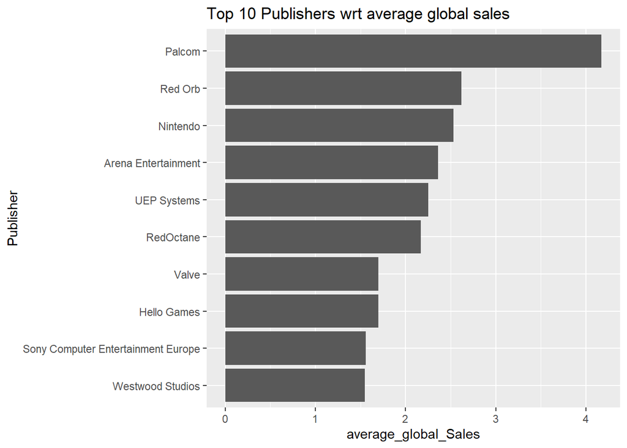

```r
#Publisher
publisher_df <- sqldf('select  Publisher , avg(Global_sales) as average_global_Sales from data where Publisher is not null group by Publisher order by average_global_Sales desc limit(10)')
ggplot(data = publisher_df, aes(x = reorder(Publisher, average_global_Sales), y = average_global_Sales)) +
  geom_bar(stat =  "identity") +
  labs(x = "Publisher" , Y = "average global sales" , title = "Top 10 Publishers wrt average global sales") +
  coord_flip()
```

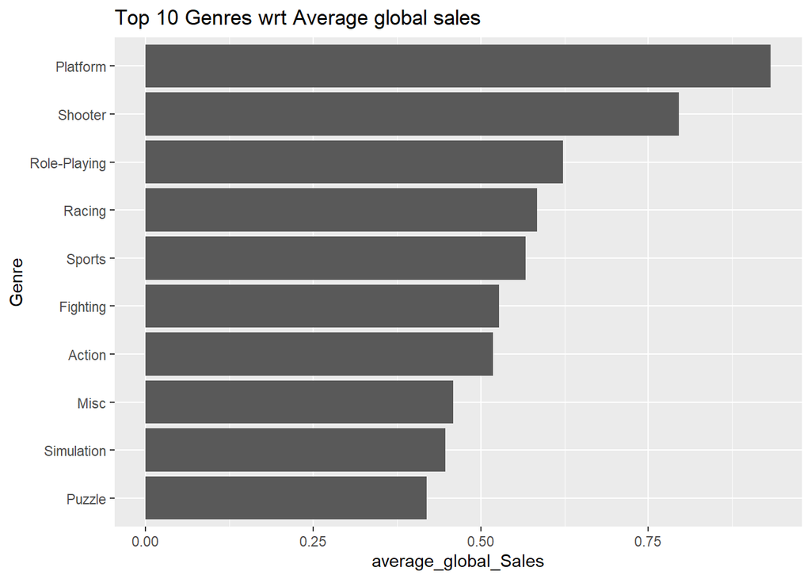

```r
#Genre
genre_df <- sqldf('select  Genre , avg(Global_sales) as average_global_Sales from data where Genre is not null group by Genre order by average_global_sales desc limit(10)')
ggplot(data = genre_df, aes(x = reorder(Genre, average_global_Sales), y = average_global_Sales)) +
  geom_bar(stat =  "identity") +
  labs(x = "Genre" , Y = "average global sales" , title = "Top 10 Genres wrt Average global sales") +
  coord_flip()
```

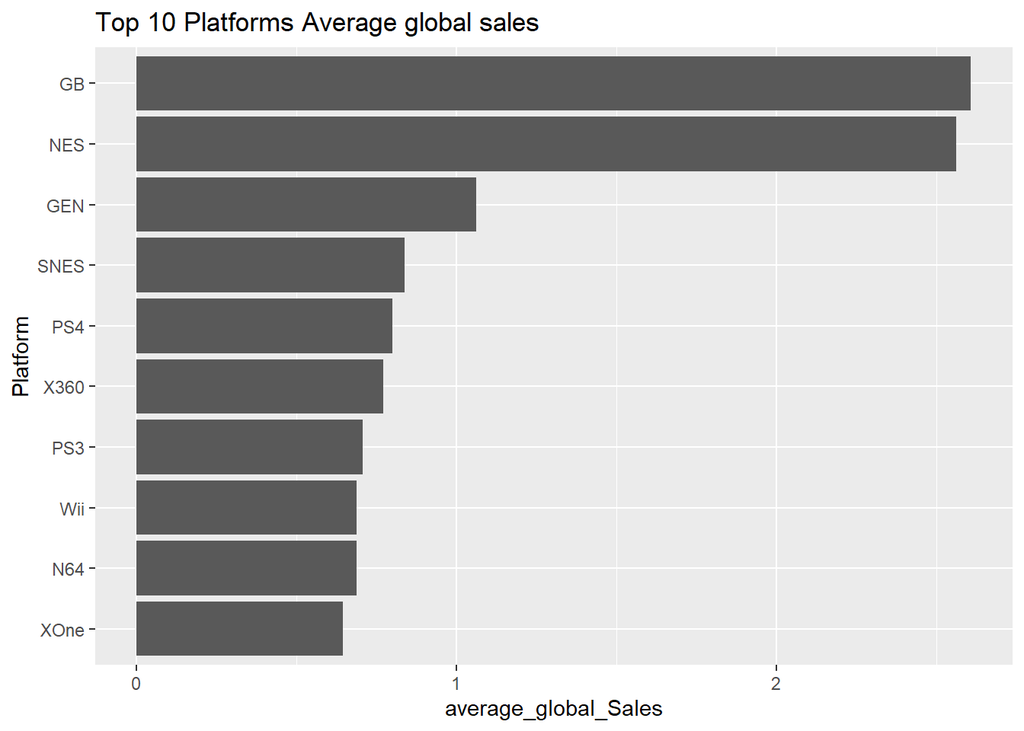

```r
#Platform
platform_df <- sqldf('select  Platform , avg(Global_sales) as average_global_Sales from data where Platform is not null group by Platform order by average_global_sales desc limit(10)')
ggplot(data = platform_df, aes(x = reorder(Platform, average_global_Sales), y = average_global_Sales)) +
  geom_bar(stat =  "identity") +
  labs(x = "Platform" , Y = "average global sales" , title = "Top 10 Platforms Average global sales") +
  coord_flip()
```

#Name of the games

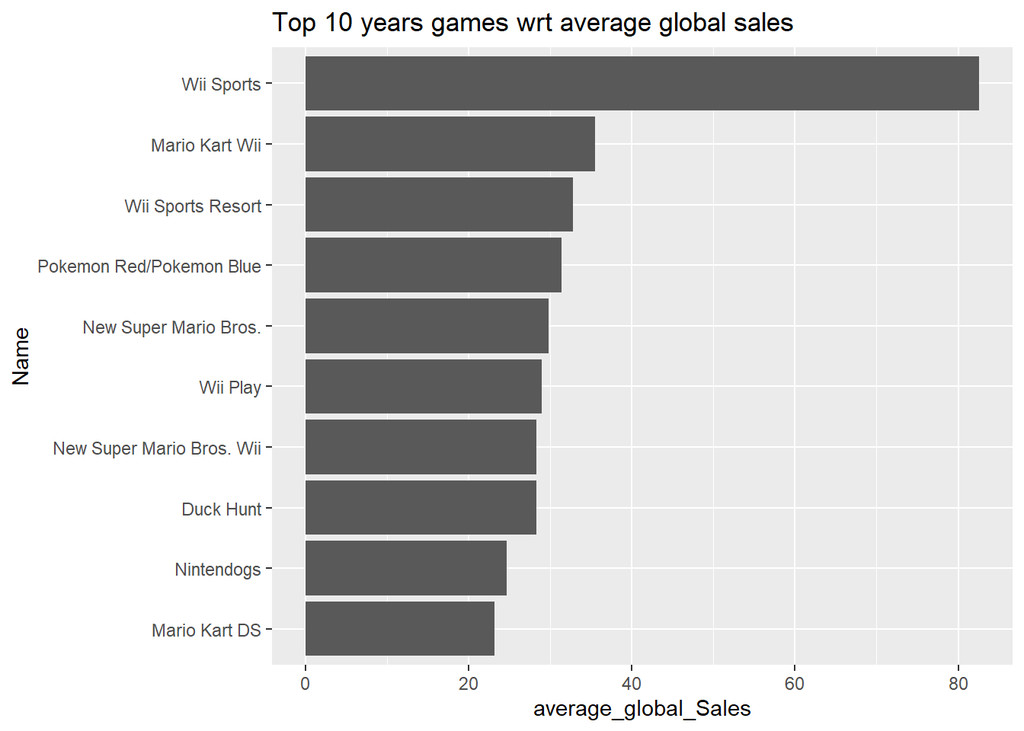

```r
name_df <- sqldf('select  Name , avg(Global_sales) as average_global_Sales from data where Name is not null group by Name order by average_global_sales desc limit(10)')
ggplot(data = name_df, aes(x = reorder(Name, average_global_Sales), y = average_global_Sales)) +
  geom_bar(stat =  "identity") +
  labs(x = "Name" , Y = "average global sales" , title = "Top 10 years games wrt average global sales")+
  coord_flip()
```

#Publisher

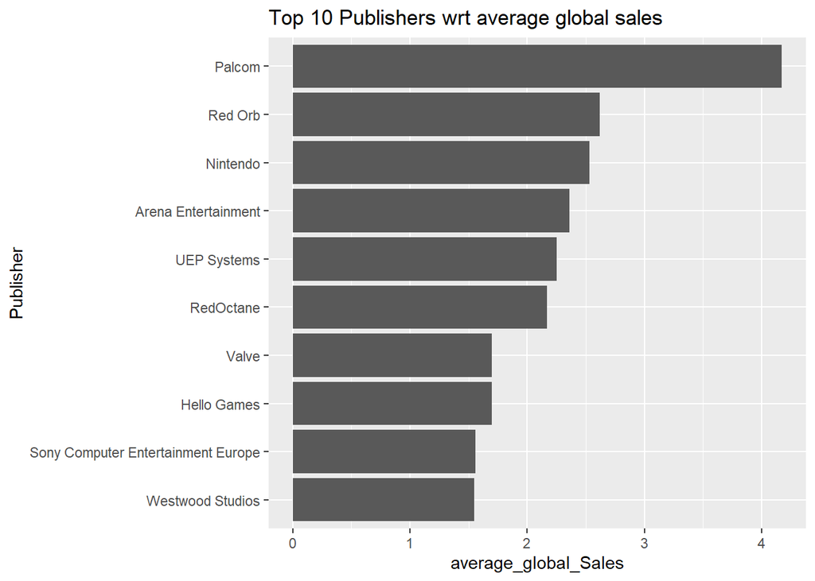

```r
publisher_df <- sqldf('select  Publisher , avg(Global_sales) as average_global_Sales from data where Publisher is not null group by Publisher order by average_global_Sales desc limit(10)')
ggplot(data = publisher_df, aes(x = reorder(Publisher, average_global_Sales), y = average_global_Sales)) +
  geom_bar(stat =  "identity") +
  labs(x = "Publisher" , Y = "average global sales" , title = "Top 10 Publishers wrt average global sales") +
  coord_flip()
```

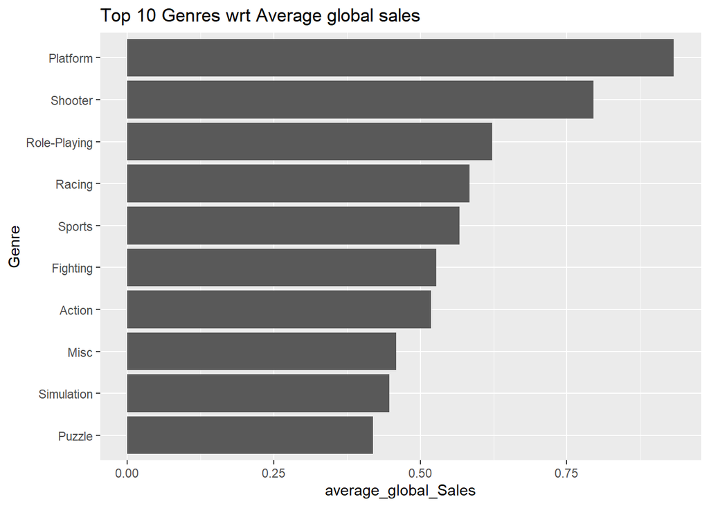

```r
#Genre
genre_df <- sqldf('select  Genre , avg(Global_sales) as average_global_Sales from data where Genre is not null group by Genre order by average_global_sales desc limit(10)')
ggplot(data = genre_df, aes(x = reorder(Genre, average_global_Sales), y = average_global_Sales)) +
  geom_bar(stat =  "identity") +
  labs(x = "Genre" , Y = "average global sales" , title = "Top 10 Genres wrt Average global sales") +
  coord_flip()
```

## Correlation between the variables

[figure not shown]

```r
data_for_model <- sqldf('select  NA_Sales, EU_Sales, JP_Sales, Other_Sales, Global_Sales, Critic_Score, User_Count from data' )

library(GGally)

ggpairs(data_for_model)
```

```r
library(tidyverse)
df_compare_sales <- data %>% filter(Genre == c('Platform','Shooter','Role-Playing')) %>%
  filter(Year_of_Release >= 2000) %>% filter(Year_of_Release <= 2015)

df_compare_sales <- df_compare_sales %>% group_by(Genre) %>%
  summarise(average_NA_sales = mean(NA_Sales),
            average_EU_sales = mean(EU_Sales),
            average_JP_sales = mean(JP_Sales),
            average_other_sales = mean(Other_Sales),
            average_global_sales = mean(Global_Sales))
df_compare_sales
```

```
## # A tibble: 3 x 6
##   Genre        average_NA_sales average_EU_sales average_JP_sales average_other_s~
##   <chr>                   <dbl>            <dbl>            <dbl>            <dbl>
## 1 Platform                0.327            0.175           0.0775           0.0510
## 2 Role-Playing            0.204            0.101           0.199            0.0361
## 3 Shooter                 0.414            0.265           0.0274           0.0946
## # ... with 1 more variable: average_global_sales <dbl>
```

```r
df_compare_sales$NA_Sales_perc <- df_compare_sales$average_NA_sales*100/df_compare_sales$average_global_sales
df_compare_sales$EU_Sales_perc <- df_compare_sales$average_EU_sales*100/df_compare_sales$average_global_sales
df_compare_sales$JP_Sales_perc <- df_compare_sales$average_JP_sales*100/df_compare_sales$average_global_sales
df_compare_sales$Other_Sales_perc <- df_compare_sales$average_other_sales*100/df_compare_sales$average_global_sales
df_compare_sales$Global_Sales_perc <- df_compare_sales$average_global_sales*100/df_compare_sales$average_global_sales



df_compare_sales_n <- df_compare_sales[c('Genre','NA_Sales_perc','EU_Sales_perc',
                                        'JP_Sales_perc','Other_Sales_perc')]
df_compare_sales_n
```

```
## # A tibble: 3 x 5
##   Genre        NA_Sales_perc EU_Sales_perc JP_Sales_perc Other_Sales_perc
##   <chr>                <dbl>         <dbl>         <dbl>            <dbl>
## 1 Platform              51.8          27.8         12.3              8.07
## 2 Role-Playing          37.8          18.7         36.8              6.70
## 3 Shooter               51.6          33.1          3.42            11.8
```

```r
## Transpose data for plots by Generes
library(reshape2)
library(data.table)
library(ggplot2)
df_compare_sales_t = data.table(df_compare_sales_n) %>% melt(id.vars = 'Genre')
df_compare_sales_t
```

```
##            Genre         variable     value
##  1:     Platform    NA_Sales_perc 51.833079
##  2: Role-Playing    NA_Sales_perc 37.807349
##  3:      Shooter    NA_Sales_perc 51.640013
##  4:     Platform    EU_Sales_perc 27.760033
##  5: Role-Playing    EU_Sales_perc 18.657335
##  6:      Shooter    EU_Sales_perc 33.108755
##  7:     Platform    JP_Sales_perc 12.262186
##  8: Role-Playing    JP_Sales_perc 36.840409
##  9:      Shooter    JP_Sales_perc  3.421864
## 10:     Platform Other_Sales_perc  8.068324
## 11: Role-Playing Other_Sales_perc  6.704116
## 12:      Shooter Other_Sales_perc 11.808092
```

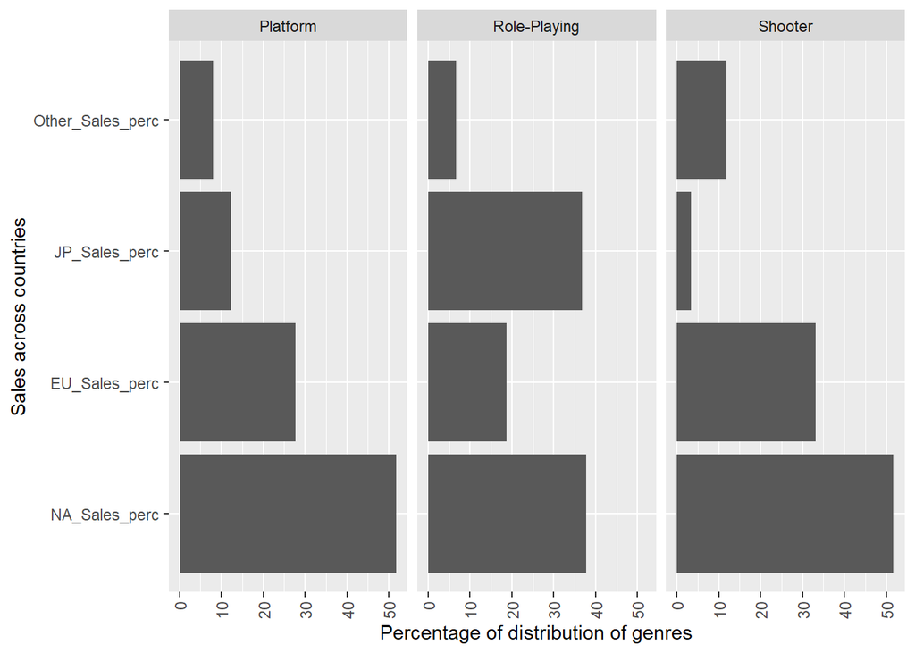

```r
p <- df_compare_sales_t %>% ggplot(aes(x= reorder(variable, -(value)), y=value))+
  geom_bar(stat='identity') +
  labs(x = "Sales across countries" , y = "Percentage of distribution of genres" , label = "Pecentage distribution of genre across the NA, EU, JP and Other sales") +
  coord_flip() +
  facet_grid(.~Genre)

p + theme(axis.text.x = element_text(angle = 90, vjust = 0.5, hjust=1))
```

```r
library(corrplot)
```

## Read and view data

```r
video_game_sales <- read.csv("C:/Users/prach/OneDrive - University of Cincinnati/Desktop/Fall 2021 courses/Data Analysis methods/final_porject_dam/Video_Games_Sales_as_at_22_Dec_2016.csv")
class(video_game_sales)
```

```
## [1] "data.frame"
```

```r
head(video_game_sales)
```

```
##                       Name Platform Year_of_Release        Genre Publisher
## 1               Wii Sports      Wii            2006       Sports  Nintendo
## 2        Super Mario Bros.      NES            1985     Platform  Nintendo
## 3           Mario Kart Wii      Wii            2008       Racing  Nintendo
## 4        Wii Sports Resort      Wii            2009       Sports  Nintendo
## 5 Pokemon Red/Pokemon Blue       GB            1996 Role-Playing  Nintendo
## 6                   Tetris       GB            1989       Puzzle  Nintendo
##   NA_Sales EU_Sales JP_Sales Other_Sales Global_Sales Critic_Score Critic_Count
## 1    41.36    28.96     3.77        8.45        82.53           76           51
## 2    29.08     3.58     6.81        0.77        40.24           NA           NA
## 3    15.68    12.76     3.79        3.29        35.52           82           73
## 4    15.61    10.93     3.28        2.95        32.77           80           73
## 5    11.27     8.89    10.22        1.00        31.37           NA           NA
## 6    23.20     2.26     4.22        0.58        30.26           NA           NA
##   User_Score User_Count Developer Rating
## 1          8        322  Nintendo      E
## 2                    NA
## 3        8.3        709  Nintendo      E
## 4          8        192  Nintendo      E
## 5                    NA
## 6                    NA
```

```r
nrow(video_game_sales)
```

```
## [1] 16719
```

```r
video_game_sales$User_Score <- as.numeric(video_game_sales$User_Score)
video_game_sales$Year_of_Release <- as.numeric(video_game_sales$Year_of_Release)
summary.default(video_game_sales)
```

```
##                 Length Class  Mode
## Name            16719  -none- character
## Platform        16719  -none- character
## Year_of_Release 16719  -none- numeric
## Genre           16719  -none- character
## Publisher       16719  -none- character
## NA_Sales        16719  -none- numeric
## EU_Sales        16719  -none- numeric
## JP_Sales        16719  -none- numeric
## Other_Sales     16719  -none- numeric
## Global_Sales    16719  -none- numeric
## Critic_Score    16719  -none- numeric
## Critic_Count    16719  -none- numeric
## User_Score      16719  -none- numeric
## User_Count      16719  -none- numeric
## Developer       16719  -none- character
## Rating          16719  -none- character
```

## Clean data

```r
video_game_sales <- na.omit(video_game_sales)
video_game_sales <- video_game_sales[!(video_game_sales$Platform==2600),]
head(video_game_sales)
```

```
##                        Name Platform Year_of_Release    Genre Publisher
## 1                Wii Sports      Wii            2006   Sports  Nintendo
## 3            Mario Kart Wii      Wii            2008   Racing  Nintendo
## 4         Wii Sports Resort      Wii            2009   Sports  Nintendo
## 7     New Super Mario Bros.       DS            2006 Platform  Nintendo
## 8                  Wii Play      Wii            2006     Misc  Nintendo
## 9 New Super Mario Bros. Wii      Wii            2009 Platform  Nintendo
##   NA_Sales EU_Sales JP_Sales Other_Sales Global_Sales Critic_Score Critic_Count
## 1    41.36    28.96     3.77        8.45        82.53           76           51
## 3    15.68    12.76     3.79        3.29        35.52           82           73
## 4    15.61    10.93     3.28        2.95        32.77           80           73
## 7    11.28     9.14     6.50        2.88        29.80           89           65
## 8    13.96     9.18     2.93        2.84        28.92           58           41
## 9    14.44     6.94     4.70        2.24        28.32           87           80
##   User_Score User_Count Developer Rating
## 1        8.0        322  Nintendo      E
## 3        8.3        709  Nintendo      E
## 4        8.0        192  Nintendo      E
## 7        8.5        431  Nintendo      E
## 8        6.6        129  Nintendo      E
## 9        8.4        594  Nintendo      E
```

```r
nrow(video_game_sales)
```

```
## [1] 6894
```

## Look for visual correlation

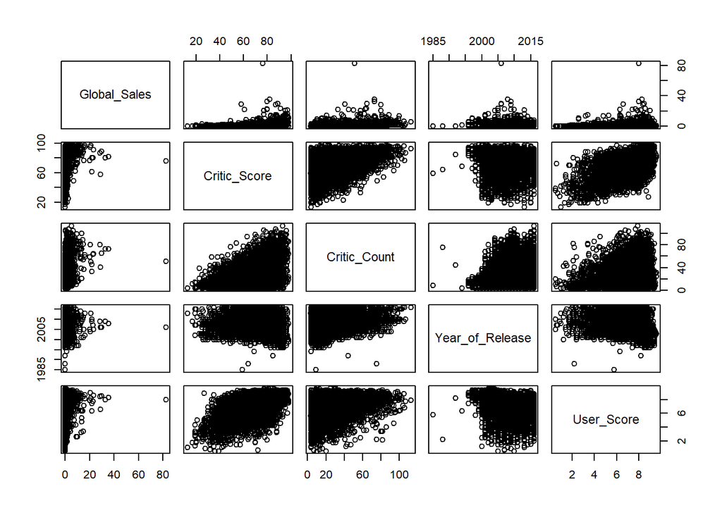

```r
pairs(~Global_Sales + Critic_Score + Critic_Count + Year_of_Release + User_Score, data = video_game_sales)
```

## Initial Linear Regression with categorical variables

Many of the independent variables in the video game dataset are categorical fields. These categorical fields also have many unique values so it makes sense to run a couple of regressions on them initially to see if they are even useful.

The first categorical variable is Publisher. Running a linear regression with Publisher as a factor variable (dummy variables) shows that none of the publishers differ from the others in a statistically significant way.

```r
global_sales_lm_publisher <- lm(Global_Sales~factor(Publisher), data=video_game_sales)
summary(global_sales_lm_publisher)
```

```
##
## Call:
## lm(formula = Global_Sales ~ factor(Publisher), data = video_game_sales)
##
## Residuals:
##    Min     1Q Median     3Q    Max
## -2.892 -0.529 -0.210  0.051 79.628
##
## Coefficients:
##                                                           Estimate Std. Error
## (Intercept)                                              1.600e-01  1.903e+00
## factor(Publisher)10TACLE Studios                        -1.400e-01  2.691e+00
## factor(Publisher)1C Company                             -1.267e-01  2.197e+00
## factor(Publisher)2D Boy                                 -1.200e-01  2.691e+00
## factor(Publisher)3DO                                     5.333e-03  1.965e+00
## factor(Publisher)505 Games                               2.364e-01  1.914e+00
## factor(Publisher)5pb                                    -1.200e-01  2.691e+00
## factor(Publisher)Acclaim Entertainment                   1.361e-01  1.917e+00
## factor(Publisher)Ackkstudios                            -6.000e-02  2.691e+00
## factor(Publisher)Acquire                                -2.000e-02  2.691e+00
## factor(Publisher)Activision                              9.289e-01  1.904e+00
## factor(Publisher)Activision Blizzard                     3.100e-01  2.691e+00
## factor(Publisher)Activision Value                       -2.500e-02  2.055e+00
## factor(Publisher)Agatsuma Entertainment                 -4.500e-02  2.330e+00
## factor(Publisher)Agetec                                 -1.500e-02  2.330e+00
## factor(Publisher)Aksys Games                            -9.833e-02  2.055e+00
## factor(Publisher)Alternative Software                   -1.200e-01  2.691e+00
## factor(Publisher)AQ Interactive                          3.000e-02  2.330e+00
## factor(Publisher)Aqua Plus                              -5.000e-02  2.691e+00
## factor(Publisher)Arc System Works                       -5.750e-02  2.127e+00
## factor(Publisher)Ascaron Entertainment GmbH             -1.100e-01  2.330e+00
## factor(Publisher)ASCII Entertainment                     3.400e-01  2.691e+00
## factor(Publisher)Aspyr                                  -1.050e-01  2.330e+00
## factor(Publisher)Astragon                               -1.250e-01  2.330e+00
## factor(Publisher)Atari                                   3.099e-01  1.908e+00
## factor(Publisher)Atlus                                   1.124e-01  1.940e+00
## factor(Publisher)Avalon Interactive                     -1.067e-01  2.197e+00
## factor(Publisher)Avanquest                              -1.400e-01  2.330e+00
## factor(Publisher)BAM! Entertainment                      2.700e-02  1.995e+00
## factor(Publisher)Banpresto                              -1.250e-02  2.127e+00
```

[output cut: 504 more lines]

```
## factor(Publisher)Wargaming.net                            0.048    0.961
## factor(Publisher)Warner Bros. Interactive Entertainment   0.354    0.723
## factor(Publisher)White Park Bay Software                 -0.004    0.997
## factor(Publisher)Xicat Interactive                       -0.048    0.961
## factor(Publisher)Xplosiv                                  0.075    0.940
## factor(Publisher)XS Games                                -0.015    0.988
## factor(Publisher)Xseed Games                              0.028    0.977
## factor(Publisher)Yacht Club Games                        -0.036    0.971
## factor(Publisher)Zoo Digital Publishing                   0.018    0.986
## factor(Publisher)Zoo Games                                0.130    0.896
## factor(Publisher)Zushi Games                              0.019    0.985
##
## Residual standard error: 1.903 on 6622 degrees of freedom
## Multiple R-squared:  0.09001,    Adjusted R-squared:  0.05277
## F-statistic: 2.417 on 271 and 6622 DF,  p-value: < 2.2e-16
```

[output not shown]

[output not shown]

Now that the categorical variables have been looked through, it’s important to investigate the quantitative variables. Since 4 of the variables are: NA_Sales, EU_Sales, JP_Sales, and Other_Sales, and these variables total up to Global_Sales, which we are trying to predict, we will leave these out.

This leaves Critic_Score, Critic_Count, User_Score, and User_Count as quantitative variables that may be used to predict Global_Sales.

Intuitively, it makes sense that higher rated games *may* sell more units globally.

However, R squared and adjusted R squared are both below 13%

```r
global_sales_lm <- lm(Global_Sales~., data=subset(video_game_sales, select = c(Global_Sales, Critic_Score, Critic_Count, User_Score, User_Count)))
summary(global_sales_lm)
```

```
##
## Call:
## lm(formula = Global_Sales ~ ., data = subset(video_game_sales,
##     select = c(Global_Sales, Critic_Score, Critic_Count, User_Score,
##         User_Count)))
##
## Residuals:
##    Min     1Q Median     3Q    Max
## -6.097 -0.559 -0.228  0.179 81.188
##
## Coefficients:
##                Estimate Std. Error t value Pr(>|t|)
## (Intercept)  -9.437e-01  1.275e-01  -7.402  1.5e-13 ***
## Critic_Score  1.985e-02  2.131e-03   9.314  < 2e-16 ***
## Critic_Count  1.860e-02  1.306e-03  14.236  < 2e-16 ***
## User_Score   -4.304e-02  1.905e-02  -2.259   0.0239 *
## User_Count    5.363e-04  4.143e-05  12.943  < 2e-16 ***
## ---
## Signif. codes:  0 '***' 0.001 '**' 0.01 '*' 0.05 '.' 0.1 ' ' 1
##
## Residual standard error: 1.828 on 6889 degrees of freedom
## Multiple R-squared:  0.126,  Adjusted R-squared:  0.1255
## F-statistic: 248.3 on 4 and 6889 DF,  p-value: < 2.2e-16
```

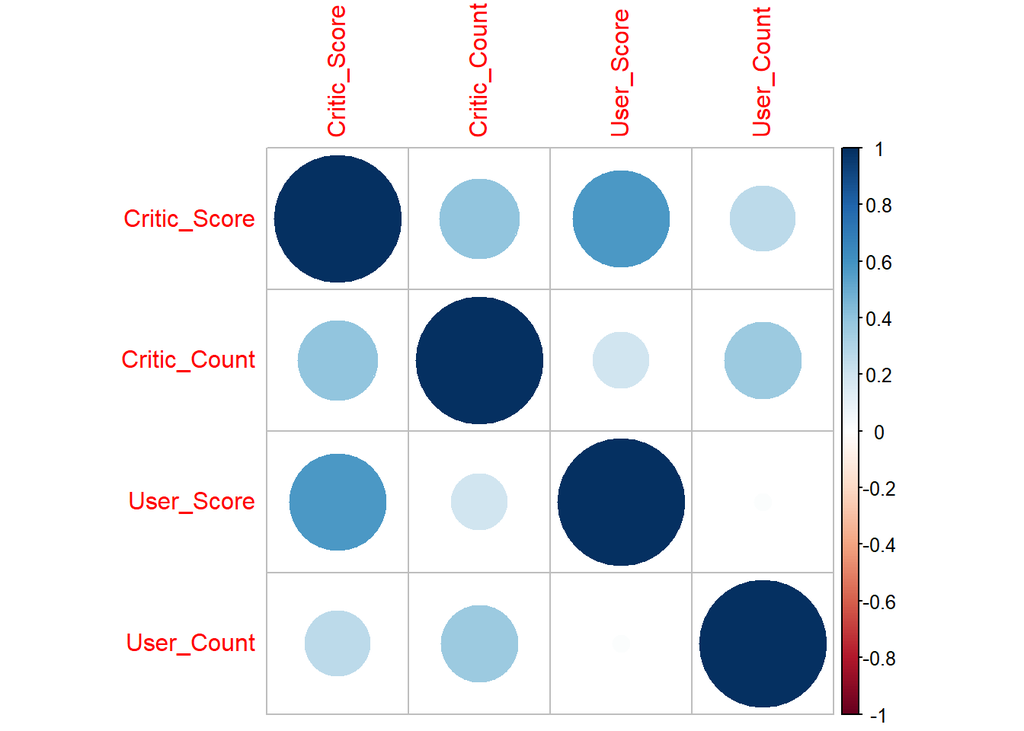

```r
corrplot(cor(subset(video_game_sales, select = c(Critic_Score, Critic_Count, User_Score, User_Count))))
```

```r
global_sales_lm <- lm(Global_Sales~., data=subset(video_game_sales, select = c(Global_Sales, Critic_Score)))
summary(global_sales_lm)
```

```
##
## Call:
## lm(formula = Global_Sales ~ ., data = subset(video_game_sales,
##     select = c(Global_Sales, Critic_Score)))
##
## Residuals:
##    Min     1Q Median     3Q    Max
## -1.525 -0.679 -0.323  0.163 81.567
##
## Coefficients:
##              Estimate Std. Error t value Pr(>|t|)
## (Intercept)  -1.57760    0.11818  -13.35   <2e-16 ***
## Critic_Score  0.03343    0.00165   20.26   <2e-16 ***
## ---
## Signif. codes:  0 '***' 0.001 '**' 0.01 '*' 0.05 '.' 0.1 ' ' 1
##
## Residual standard error: 1.899 on 6892 degrees of freedom
## Multiple R-squared:  0.05621,    Adjusted R-squared:  0.05607
## F-statistic: 410.5 on 1 and 6892 DF,  p-value: < 2.2e-16
```

A time series is a sequence where a metric is recorded over regular time intervals. Depending on the frequency, a time series can be of yearly (ex: annual budget), quarterly (ex: expenses), monthly (ex: air traffic), weekly (ex: sales qty), daily (ex: weather), hourly (ex: stocks price), minutes (ex: inbound calls in a call canter) and even seconds wise (ex: web traffic).

Forecasting is the next step where you want to predict the future values the series is going to take.

But why forecast?

Because, forecasting a time series (like demand and sales) is often of tremendous commercial value. In most manufacturing companies, it drives the fundamental business planning, procurement and production activities. Any errors in the forecasts will ripple down throughout the supply chain or any business context for that matter. So it’s important to get the forecasts accurate in order to save on costs and is critical to success.

```r
install.packages("forecast")
library(forecast)
install.packages("astsa")
library(astsa)
install.packages('plyr', repos = "http://cran.us.r-project.org")
options(repos = list(CRAN="http://cran.rstudio.com/"))


model_trainTS = ts(model_train_1)
model_testTS = ts(model_test_1)

data.ts <- as.ts(model_test_1$Global_Sales)

fit <- arima(log(data.ts), c(0, 1, 0), seasonal = list(order = c(0, 1, 0), period = 1))
data.ts <- ts(model_test_1$Global_Sales, frequency = 12, start = c(1980,1))
data.ts
```

Jan Feb Mar Apr May Jun Jul Aug Sep Oct Nov Dec

2021 1.20 1.20 1.20 1.20 1.19 1.19 1.18 1.18 1.17 1.17 1.17 1.17

2022 1.17 1.16 1.16 1.16 1.16 1.16 1.16 1.15 1.15 1.15 1.15 1.15

2023 1.15 1.15 1.15 1.15 1.14 1.14 1.14 1.14 1.14 1.14 1.14 1.14

2024 1.13 1.13 1.13 1.13 1.13 1.12 1.12 1.11 1.11 1.11 1.11 1.10

2025 1.10 1.10 1.10 1.10 1.10 1.10 1.10 1.09 1.09 1.09 1.08 1.08

2026 1.08 1.08 1.08 1.08 1.07 1.07 1.07 1.07 1.07 1.07 1.07 1.07

2027 1.07 1.06 1.06 1.06 1.06 1.06 1.06 1.05 1.05 1.05 1.05 1.05

2028 1.04 1.04 1.04 1.04 1.04 1.04 1.04 1.03 1.03 1.03 1.03 1.03

2029 1.03 1.03 1.02 1.02 1.02 1.02 1.02 1.02 1.01 1.01 1.00 1.00

2030 1.00 1.00 1.00 1.00 0.99 0.99 0.99 0.99 0.99 0.98 0.98 0.98

2031 0.98 0.97 0.97 0.97 0.97 0.97 0.97 0.97 0.97 0.96 0.96 0.96

2032 0.96 0.95 0.95 0.95 0.95 0.95 0.95 0.95 0.95 0.95 0.95 0.94

2033 0.94 0.94 0.94 0.94 0.93 0.93 0.93 0.93 0.93 0.93 0.93 0.93

2034 0.93 0.93 0.92 0.92 0.92 0.92 0.92 0.92 0.92 0.92 0.91 0.91

2035 0.91 0.91 0.91 0.90 0.90 0.90 0.90 0.90 0.90 0.90 0.89 0.89

2036 0.89 0.89 0.89 0.89 0.89 0.89 0.89 0.88 0.88 0.88 0.88 0.87

2037 0.87 0.87 0.87 0.87 0.87 0.87 0.87 0.87 0.87 0.86 0.86 0.86

2038 0.86 0.86 0.86 0.85 0.85 0.85 0.85 0.85 0.85 0.85 0.84 0.84

2039 0.84 0.84 0.84 0.84 0.84 0.84 0.84 0.83 0.83 0.83 0.83 0.83

2040 0.83 0.83 0.83 0.83 0.82 0.82 0.82 0.82 0.82 0.82 0.82 0.82

2041 0.82 0.81 0.81 0.81 0.81 0.81 0.81 0.81 0.81 0.81 0.81 0.81

2042 0.81 0.80 0.80 0.80 0.80 0.80 0.79 0.79 0.79 0.79 0.79 0.79

2043 0.79 0.79 0.78 0.78 0.78 0.78 0.78 0.78 0.78 0.78 0.78 0.78

2044 0.77 0.77 0.77 0.77 0.77 0.77 0.77 0.77 0.76 0.76 0.76 0.76

2045 0.76 0.76 0.76 0.76 0.76 0.76 0.76 0.76 0.76 0.76 0.76 0.76

2046 0.75 0.75 0.75 0.75 0.75 0.75 0.75 0.75 0.75 0.75 0.75 0.75

2047 0.75 0.74 0.74 0.74 0.74 0.74 0.74 0.74 0.74 0.74 0.74 0.73

2048 0.73 0.73 0.73 0.73 0.73 0.73 0.73 0.73 0.73 0.72 0.72 0.72

2049 0.72 0.72 0.72 0.72 0.72 0.72 0.72 0.72 0.72 0.72 0.71 0.71

2050 0.71 0.71 0.71 0.71 0.71 0.71 0.71 0.71 0.71 0.71 0.70 0.70

2051 0.70 0.70 0.70 0.70 0.70 0.70 0.70 0.70 0.69 0.69 0.69 0.69

2052 0.69 0.69 0.68 0.68 0.68 0.68 0.68 0.68 0.67 0.67 0.67 0.67

2053 0.67 0.67 0.67 0.67 0.67 0.67 0.67 0.67 0.66 0.66 0.66 0.66

2054 0.66 0.66 0.66 0.66 0.66 0.66 0.66 0.66 0.66 0.66 0.66 0.66

2055 0.66 0.66 0.66 0.66 0.65 0.65 0.65 0.65 0.65 0.65 0.64 0.64

2056 0.64 0.64 0.64 0.64 0.64 0.64 0.64 0.64 0.63 0.63 0.63 0.63

2057 0.63 0.63 0.63 0.63 0.63 0.63 0.63 0.63 0.63 0.62 0.62 0.62

2058 0.62 0.62 0.62 0.62 0.62 0.62 0.62 0.62 0.62 0.62 0.62 0.62

2059 0.62 0.61 0.61 0.61 0.61 0.61 0.61 0.61 0.61 0.61 0.61 0.61

2060 0.61 0.61 0.61 0.61 0.61 0.60 0.60 0.60 0.60 0.60 0.60 0.60

2061 0.60 0.60 0.60 0.60 0.60 0.60 0.60 0.60 0.59 0.59 0.59 0.59

2062 0.59 0.59 0.59 0.59 0.59 0.59 0.59 0.59 0.59 0.59 0.59 0.58

[ reached getOption(“max.print”) – omitted 335 rows ]

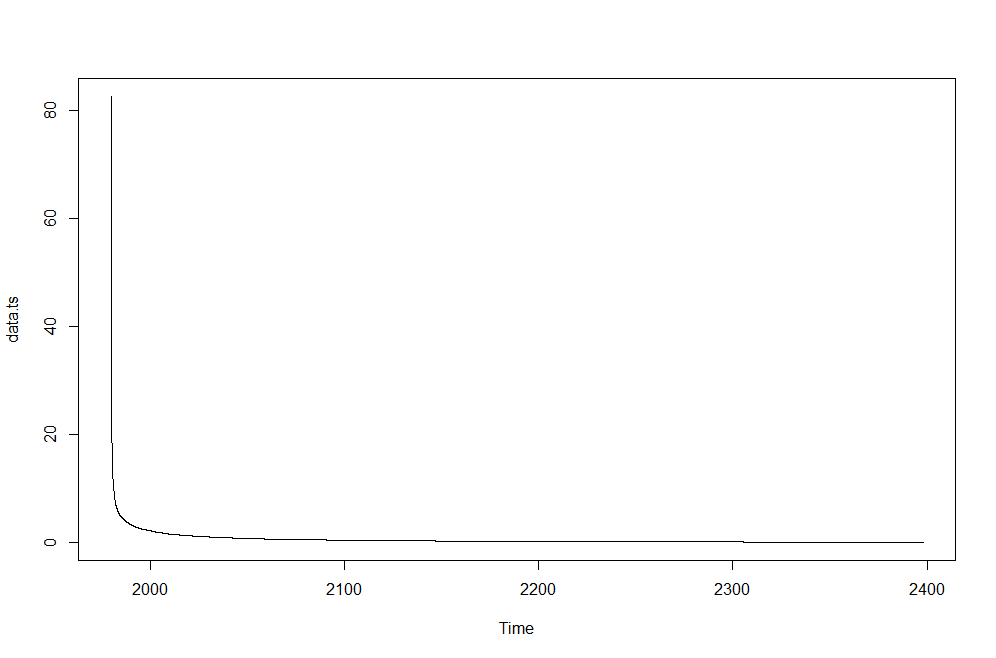

```r
install.packages("contrib.url", repos = "http://cran.us.r-project.org")
plot(data.ts)
```

## Conculsion

Based on our analysis, as we obserevd that the sales of the video games decreased with recent years, based on how the gaming industry has eveolved, we had a hypothesis that with in the coming years there is going to be a decrease in the video games sales in the coming years, since there are very less people who prefer having a physical copy of game, with extreme developements in technology, people in the future won’t face the problem of memory space, hence the people who will opt for the physical copies of the video games are the people who have a knack to collect the physical copies of the games and are looking for discounts. Other sales that would be generated would be through digital selling of the games, similar to what we have been opting for more recently.